# Tarea 04: Ejercicios Unidad 02-A | Bisección

### CONJUNTO DE EJERCICIOS

- Mateo Molina Moises Estrella

**Link Repositorio:** https://github.com/R3LM15/MetodosNumericos_MateoMolina

1. Use el método de bisección para encontrar soluciones precisas dentro de $ 10^{-2}$ para $ x^{3} -7x^{2} + 14x-6=0$ en cada intervalo.

   a. $ [0,1] $ b. $[1, 3.2]$ c. $[3.2, 4]$

```python
def f(x):
    return x**3 - 7*x**2 + 14*x - 6

def biseccion(a, b, tol=1e-2, max_iter=50):
    print(f"\nIntervalo inicial: [{a}, {b}]")
    if f(a) * f(b) >= 0:
        print("El método de bisección no se puede aplicar: f(a) y f(b) deben tener signos opuestos.")
        return None

    iteracion = 0
    while abs(b - a) > tol and iteracion < max_iter:
        c = (a + b) / 2.0

        if f(c) == 0:
            return c  # Se encontró la raíz exacta
        elif f(a) * f(c) < 0:
            b = c
        else:
            a = c
        iteracion += 1




        print(f"Iteración {iteracion}: c = {c}, f(c) = {f(c)} rango = [{a}, {b}]")
    return (a + b) / 2.0

# Intervalos
raiz = biseccion(0, 1)
print(f"\nRaíz aproximada: {raiz}")

# Intervalos
raiz = biseccion(1, 3.2)
print(f"\nRaíz aproximada: {raiz}")

# Intervalos
raiz = biseccion(3.2, 4)
print(f"\nRaíz aproximada: {raiz}")
```

```
Intervalo inicial: [0, 1]
Iteración 1: c = 0.5, f(c) = -0.625 rango = [0.5, 1]
Iteración 2: c = 0.75, f(c) = 0.984375 rango = [0.5, 0.75]
Iteración 3: c = 0.625, f(c) = 0.259765625 rango = [0.5, 0.625]
Iteración 4: c = 0.5625, f(c) = -0.161865234375 rango = [0.5625, 0.625]
Iteración 5: c = 0.59375, f(c) = 0.054046630859375 rango = [0.5625, 0.59375]
Iteración 6: c = 0.578125, f(c) = -0.052623748779296875 rango = [0.578125, 0.59375]
Iteración 7: c = 0.5859375, f(c) = 0.0010313987731933594 rango = [0.578125, 0.5859375]

Raíz aproximada: 0.58203125

Intervalo inicial: [1, 3.2]
Iteración 1: c = 2.1, f(c) = 1.7910000000000004 rango = [2.1, 3.2]
Iteración 2: c = 2.6500000000000004, f(c) = 0.5521250000000038 rango = [2.6500000000000004, 3.2]
Iteración 3: c = 2.9250000000000003, f(c) = 0.08582812500000614 rango = [2.9250000000000003, 3.2]
Iteración 4: c = 3.0625, f(c) = -0.054443359375 rango = [2.9250000000000003, 3.0625]
Iteración 5: c = 2.9937500000000004, f(c) = 0.006327880859373636 rango = [2.9937500000000004, 3.0625]
Iteración 6: c = 3.028125, f(c) = -0.02652072143553852 rango = [2.9937500000000004, 3.028125]
Iteración 7: c = 3.0109375000000003, f(c) = -0.010696933746345394 rango = [2.9937500000000004, 3.0109375000000003]
Iteración 8: c = 3.0023437500000005, f(c) = -0.0023327507972794592 rango = [2.9937500000000004, 3.0023437500000005]

Raíz aproximada: 2.9980468750000004

Intervalo inicial: [3.2, 4]
Iteración 1: c = 3.6, f(c) = 0.3360000000000056 rango = [3.2, 3.6]
Iteración 2: c = 3.4000000000000004, f(c) = -0.015999999999998238 rango = [3.4000000000000004, 3.6]
Iteración 3: c = 3.5, f(c) = 0.125 rango = [3.4000000000000004, 3.5]
Iteración 4: c = 3.45, f(c) = 0.046125000000003524 rango = [3.4000000000000004, 3.45]
Iteración 5: c = 3.4250000000000003, f(c) = 0.013015625000001307 rango = [3.4000000000000004, 3.4250000000000003]
Iteración 6: c = 3.4125000000000005, f(c) = -0.0019980468750020464 rango = [3.4125000000000005, 3.4250000000000003]
Iteración 7: c = 3.41875, f(c) = 0.005381591796883356 rango = [3.4125000000000005, 3.41875]

Raíz aproximada: 3.4156250000000004
```

2. a. Dibuje las gráficas para 𝑦 = 𝑥 y 𝑦 = sin x.

   b. Use el método de bisección para encontrar soluciones precisas dentro de $10^{-5} $ para el primer valor positivo de x con $x = 2 sin x $.

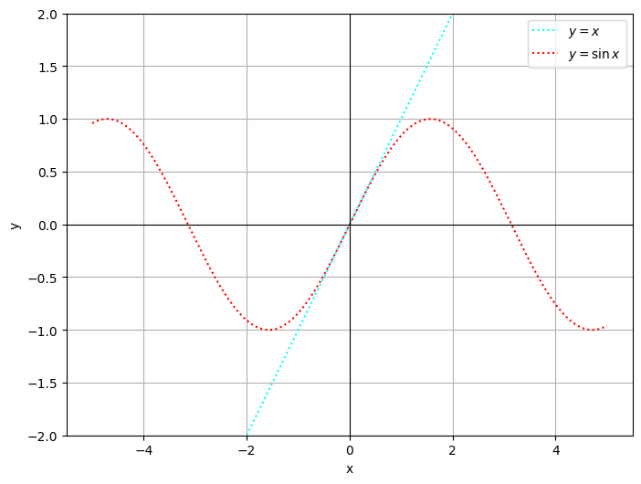

```python
import numpy as np
import matplotlib.pyplot as plt

## a)

x=np.linspace(-5, 5, 800)
y1 = x
y2 = np.sin(x)

plt.figure(figsize=(8, 6)) #tamaño de la figura
plt.plot(x, y1, label='$y = x$', color='cyan', linestyle=':')
plt.plot(x, y2, label='$y = \sin x$', color='red', linestyle=':')
plt.xlabel('x')
plt.ylabel('y')

plt.grid(True)
plt.axhline(0, color='black', linewidth=0.8)  # Eje X
plt.axvline(0, color='black', linewidth=0.8)  # Eje Y
plt.legend()
plt.ylim(-2, 2)  # Limita el eje Y para evitar asintotas demasiado altas
plt.show()
```

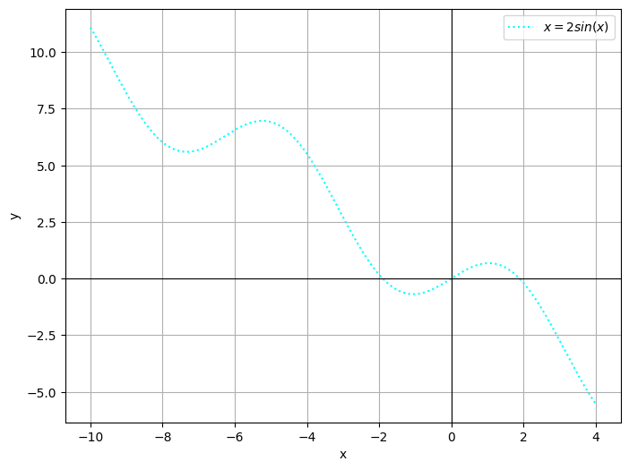

```
Intervalo inicial: [1, 2]
Iteración 1: c = 1.5, f(c) = 0.4949899732081089 rango = [1.5, 2]
Iteración 2: c = 1.75, f(c) = 0.21797189374787385 rango = [1.75, 2]
Iteración 3: c = 1.875, f(c) = 0.033171563219387634 rango = [1.875, 2]
Iteración 4: c = 1.9375, f(c) = -0.0704714382752476 rango = [1.875, 1.9375]
Iteración 5: c = 1.90625, f(c) = -0.01772788262849101 rango = [1.875, 1.90625]
Iteración 6: c = 1.890625, f(c) = 0.007953595662794077 rango = [1.890625, 1.90625]
Iteración 7: c = 1.8984375, f(c) = -0.0048293554422849105 rango = [1.890625, 1.8984375]
Iteración 8: c = 1.89453125, f(c) = 0.001576586246616385 rango = [1.89453125, 1.8984375]
Iteración 9: c = 1.896484375, f(c) = -0.001622770437292198 rango = [1.89453125, 1.896484375]
Iteración 10: c = 1.8955078125, f(c) = -2.2188257431166036e-05 rango = [1.89453125, 1.8955078125]
Iteración 11: c = 1.89501953125, f(c) = 0.0007774249911964848 rango = [1.89501953125, 1.8955078125]
Iteración 12: c = 1.895263671875, f(c) = 0.00037767486139683726 rango = [1.895263671875, 1.8955078125]
Iteración 13: c = 1.8953857421875, f(c) = 0.00017775742503145509 rango = [1.8953857421875, 1.8955078125]
Iteración 14: c = 1.89544677734375, f(c) = 7.778811448977407e-05 rango = [1.89544677734375, 1.8955078125]
Iteración 15: c = 1.895477294921875, f(c) = 2.78008111924688e-05 rango = [1.895477294921875, 1.8955078125]
Iteración 16: c = 1.8954925537109375, f(c) = 2.806497545249087e-06 rango = [1.8954925537109375, 1.8955078125]
Iteración 17: c = 1.8955001831054688, f(c) = -9.69082477686456e-06 rango = [1.8954925537109375, 1.8955001831054688]

Raíz aproximada: 1.8954963684082031
```

```python
# Gráfica de la función
x=np.linspace(-10, 4, 800)
y1 = 2 * np.sin(x) - x

plt.figure(figsize=(8, 6)) #tamaño de la figura
plt.plot(x, y1, label='$x = 2sin(x)$', color='cyan', linestyle=':')
plt.xlabel('x')
plt.ylabel('y')

plt.grid(True)
plt.axhline(0, color='black', linewidth=0.8)  # Eje X
plt.axvline(0, color='black', linewidth=0.8)  # Eje Y
plt.legend()
plt.show()

# b)

def f(x):
    return 2 * np.sin(x) - x

def biseccion(a, b, tol=1e-5, max_iter=50):
    print(f"\nIntervalo inicial: [{a}, {b}]")
    if f(a) * f(b) >= 0:
        print("El método de bisección no se puede aplicar: f(a) y f(b) deben tener signos opuestos.")
        return None

    iteracion = 0
    while abs(b - a) > tol and iteracion < max_iter:
        c = (a + b) / 2.0

        if f(c) == 0:
            return c  # Se encontró la raíz exacta
        elif f(a) * f(c) < 0:
            b = c
        else:
            a = c
        iteracion += 1




        print(f"Iteración {iteracion}: c = {c}, f(c) = {f(c)} rango = [{a}, {b}]")
    return (a + b) / 2.0

# Intervalos
raiz = biseccion(1, 2)
print(f"\nRaíz aproximada: {raiz}")
```

3. a. Dibuje las gráficas para $ y = x $ y $ y = tan x $

   b. Use el método de bisección para encontrar una aproximación dentro de $10^{-5}$ para el primer valor positivo x con $x = tan x $

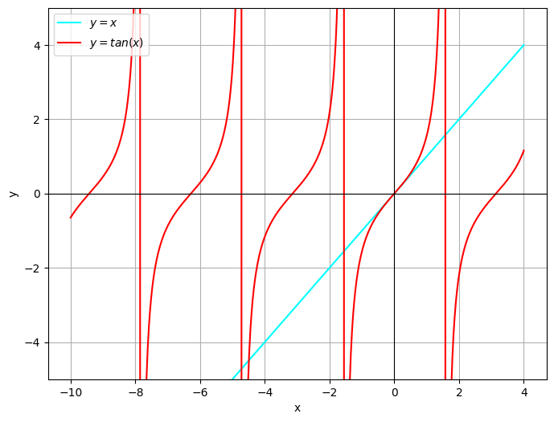

```python
## a)

x = np.linspace(-10, 4, 800)

# Definir las funciones
y1 = x
y2 = np.tan(x)

# Graficar
plt.figure(figsize=(8, 6))
plt.plot(x, y1, label='$y = x$', color='cyan')
plt.plot(x, y2, label='$y = tan(x)$', color='red')

plt.xlabel('x')
plt.ylabel('y')
plt.grid(True)

# Ejes
plt.axhline(0, color='black', linewidth=0.8)
plt.axvline(0, color='black', linewidth=0.8)

plt.legend()
plt.ylim(-5, 5)  # Limita el eje Y para evitar asintotas demasiado altas
plt.show()
```

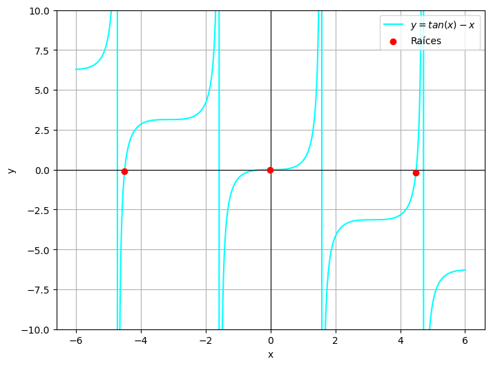

```
Intervalo inicial: [4, 4.5]
Iteración 1: c = 4.25, f(c) = -2.2436909721419407 rango = [4.25, 4.5]
Iteración 2: c = 4.375, f(c) = -1.5243878649858025 rango = [4.375, 4.5]
Iteración 3: c = 4.4375, f(c) = -0.8917623433612674 rango = [4.4375, 4.5]
Iteración 4: c = 4.46875, f(c) = -0.4458526791021189 rango = [4.46875, 4.5]
Iteración 5: c = 4.484375, f(c) = -0.1749484129144534 rango = [4.484375, 4.5]
Iteración 6: c = 4.4921875, f(c) = -0.02453083095561226 rango = [4.4921875, 4.5]
Iteración 7: c = 4.49609375, f(c) = 0.05489241988294591 rango = [4.4921875, 4.49609375]
Iteración 8: c = 4.494140625, f(c) = 0.014813871216364127 rango = [4.4921875, 4.494140625]
Iteración 9: c = 4.4931640625, f(c) = -0.004948984552007651 rango = [4.4931640625, 4.494140625]
Iteración 10: c = 4.49365234375, f(c) = 0.004909665605973501 rango = [4.4931640625, 4.49365234375]
Iteración 11: c = 4.493408203125, f(c) = -2.533485451738926e-05 rango = [4.493408203125, 4.49365234375]
Iteración 12: c = 4.4935302734375, f(c) = 0.002440744155737029 rango = [4.493408203125, 4.4935302734375]
Iteración 13: c = 4.49346923828125, f(c) = 0.0012073496428532948 rango = [4.493408203125, 4.49346923828125]
Iteración 14: c = 4.493438720703125, f(c) = 0.000590918679347574 rango = [4.493408203125, 4.493438720703125]
Iteración 15: c = 4.4934234619140625, f(c) = 0.0002827697383471772 rango = [4.493408203125, 4.4934234619140625]
Iteración 16: c = 4.493415832519531, f(c) = 0.00012871189897811774 rango = [4.493408203125, 4.493415832519531]

Raíz aproximada: 4.493412017822266
```

```python
## b)
import numpy as np
import matplotlib.pyplot as plt

# Definir el rango de x y la función
x = np.linspace(-6, 6, 800)
y1 = np.tan(x) - x

# Crear la figura
plt.figure(figsize=(8, 6))
plt.plot(x, y1, label='$y = tan(x) - x$', color='cyan')
plt.xlabel('x')
plt.ylabel('y')

# Añadir ejes y cuadrícula
plt.grid(True)
plt.axhline(0, color='black', linewidth=0.8)  # Eje X
plt.axvline(0, color='black', linewidth=0.8)  # Eje Y

# Encontrar las raíces (aproximadas)
# Usamos np.diff para detectar cambios de signo en y1
roots_indices = np.where(np.diff(np.sign(y1)))[0]
roots_x = x[roots_indices]
roots_y = y1[roots_indices]

# Marcar las raíces con puntos rojos
plt.scatter(roots_x, roots_y, color='red', label='Raíces', zorder=5)

# Ajustar límites y leyenda
plt.ylim(-10, 10)
plt.legend()

plt.show()

# b)

def f(x):
    return np.tan(x) - x

def biseccion(a, b, tol=1e-5, max_iter=50):
    print(f"\nIntervalo inicial: [{a}, {b}]")
    if f(a) * f(b) >= 0:
        print("El método de bisección no se puede aplicar: f(a) y f(b) deben tener signos opuestos.")
        return None

    iteracion = 0
    while abs(b - a) > tol and iteracion < max_iter:
        c = (a + b) / 2.0

        if f(c) == 0:
            return c  # Se encontró la raíz exacta
        elif f(a) * f(c) < 0:
            b = c
        else:
            a = c
        iteracion += 1

        print(f"Iteración {iteracion}: c = {c}, f(c) = {f(c)} rango = [{a}, {b}]")
    return (a + b) / 2.0

# Intervalos
raiz = biseccion(4, 4.5)
print(f"\nRaíz aproximada: {raiz}")
```

4. a. Dibuje las gráficas para $ y = x^{2} -1$ y $ y = e^{1-x^{2}}$

   b. Use el método de bisección para encontrar una aproximación dentro de $10 ^{-3} $ para un valor en [−2, 0] con $ x ^{2} -1 = e^{1-x^{2}} $.

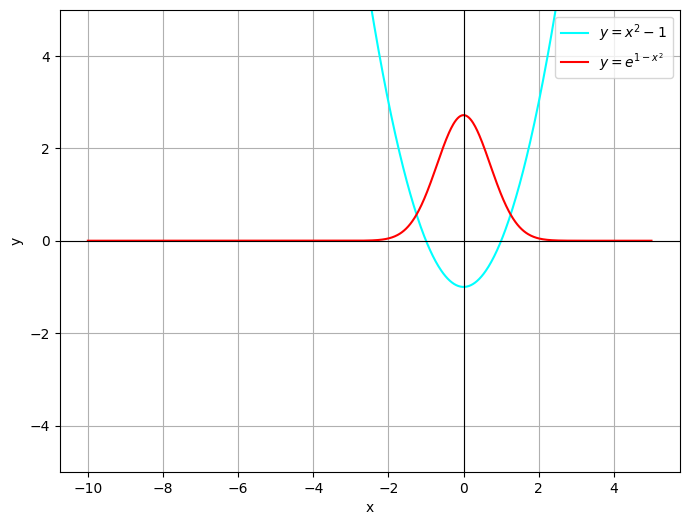

```python
## a)

x = np.linspace(-10, 5, 800)

# Definir las funciones
y1 = x**(2) -1
y2 = np.exp(1-x**2)

# Graficar
plt.figure(figsize=(8, 6))
plt.plot(x, y1, label='$y = x^{2} -1$', color='cyan')
plt.plot(x, y2, label='$y = e^{1-x^{2}}$', color='red')

plt.xlabel('x')
plt.ylabel('y')
plt.grid(True)

# Ejes
plt.axhline(0, color='black', linewidth=0.8)
plt.axvline(0, color='black', linewidth=0.8)

plt.legend()
plt.ylim(-5, 5)  # Limita el eje Y para evitar asintotas demasiado altas
plt.show()
```

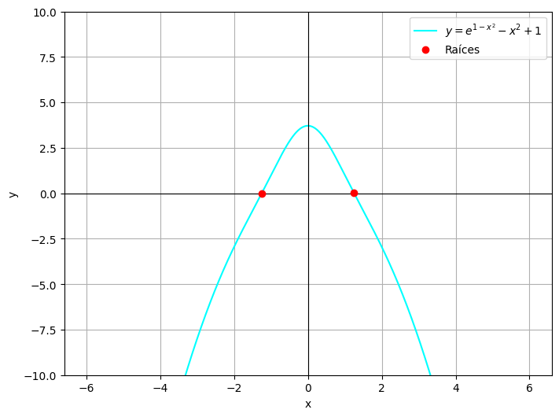

```
Intervalo inicial: [-2, 0]
Iteración 1: c = -1.0, f(c) = 1.0 rango = [-2, -1.0]
Iteración 2: c = -1.5, f(c) = -0.9634952031398099 rango = [-1.5, -1.0]
Iteración 3: c = -1.25, f(c) = 0.00728282473092301 rango = [-1.5, -1.25]
Iteración 4: c = -1.375, f(c) = -0.4802258269036299 rango = [-1.375, -1.25]
Iteración 5: c = -1.3125, f(c) = -0.2371952140591329 rango = [-1.3125, -1.25]
Iteración 6: c = -1.28125, f(c) = -0.11515295433753137 rango = [-1.28125, -1.25]
Iteración 7: c = -1.265625, f(c) = -0.05398561482037567 rango = [-1.265625, -1.25]
Iteración 8: c = -1.2578125, f(c) = -0.02336416096493732 rango = [-1.2578125, -1.25]
Iteración 9: c = -1.25390625, f(c) = -0.008043872959257126 rango = [-1.25390625, -1.25]
Iteración 10: c = -1.251953125, f(c) = -0.0003813268241048551 rango = [-1.251953125, -1.25]
Iteración 11: c = -1.2509765625, f(c) = 0.0034505480992705895 rango = [-1.251953125, -1.2509765625]

Raíz aproximada: -1.25146484375
```

```python
## b)
import numpy as np
import matplotlib.pyplot as plt

# Definir el rango de x y la función
x = np.linspace(-6, 6, 800)
y1 = np.exp(1-x**2) - x**(2) +1

# Crear la figura
plt.figure(figsize=(8, 6))
plt.plot(x, y1, label='$y = e^{1-x^{2}} - x^{2} +1$' , color='cyan')
plt.xlabel('x')
plt.ylabel('y')

# Añadir ejes y cuadrícula
plt.grid(True)
plt.axhline(0, color='black', linewidth=0.8)  # Eje X
plt.axvline(0, color='black', linewidth=0.8)  # Eje Y

# Encontrar las raíces (aproximadas)
# Usamos np.diff para detectar cambios de signo en y1
roots_indices = np.where(np.diff(np.sign(y1)))[0]
roots_x = x[roots_indices]
roots_y = y1[roots_indices]

# Marcar las raíces con puntos rojos
plt.scatter(roots_x, roots_y, color='red', label='Raíces', zorder=5)

# Ajustar límites y leyenda
plt.ylim(-10, 10)
plt.legend()

plt.show()



def f(x):
    return np.exp(1-x**2) - x**(2) +1

def biseccion(a, b, tol=1e-3, max_iter=50):
    print(f"\nIntervalo inicial: [{a}, {b}]")
    if f(a) * f(b) >= 0:
        print("El método de bisección no se puede aplicar: f(a) y f(b) deben tener signos opuestos.")
        return None

    iteracion = 0
    while abs(b - a) >= tol and iteracion < max_iter:
        c = (a + b) / 2.0

        if f(c) == 0:
            return c  # Se encontró la raíz exacta
        elif f(a) * f(c) < 0:
            b = c
        else:
            a = c
        iteracion += 1

        print(f"Iteración {iteracion}: c = {c}, f(c) = {f(c)} rango = [{a}, {b}]")
    return (a + b) / 2.0

# Intervalos
raiz = biseccion(-2,0)
print(f"\nRaíz aproximada: {raiz}")
```

5. Sea 𝑓(𝑥) = $(𝑥 + 3)(𝑥 + 1)^2 x (x-1)^3 (x-3)$ ¿En qué cero de 𝑓 converge el método de bisección cuando se aplica en los siguientes intervalos?

   a. [-1.5,2.5] b. [-0.5, 2.4] c. [-0.5, 3]

```python
def f(x):
    return (x+3)*(x+1)**2 *x*(x-1**3)**3 *(x-3)

def biseccion(a, b, tol=0, max_iter=100):
    print(f"\nIntervalo inicial: [{a}, {b}]")
    if f(a) * f(b) >= 0:
        print(f"El método de bisección no se puede aplicar: f(a) = {f(a)} y f(b) = {f(b)}  deben tener signos opuestos.")
        return None

    iteracion = 0
    while abs(b - a) > tol and iteracion < max_iter:
        c = (a + b) / 2.0

        if f(c) == 0:
            return c  # Se encontró la raíz exacta
        elif f(a) * f(c) < 0:
            b = c
        else:
            a = c
        iteracion += 1

        print(f"Iteración {iteracion}: c = {c}, f(c) = {f(c)} rango = [{a}, {b}]")
    return (a + b) / 2.0

# Intervalos
raiz = biseccion(-1.5,2.5)
print(f"\nRaíz aproximada: {raiz}")

# Intervalos
raiz = biseccion(-0.5, 2.4)
print(f"\nRaíz aproximada: {raiz}")

# Intervalos
raiz = biseccion(-0.5, 3)
print(f"\nRaíz aproximada: {raiz}")

#intervalo de prueba
raiz = biseccion(-0.5, 3.5)
print(f"\nRaíz aproximada: {raiz}")
```

```
Intervalo inicial: [-1.5, 2.5]
El método de bisección no se puede aplicar: f(a) = -39.55078125 y f(b) = -284.23828125  deben tener signos opuestos.

Raíz aproximada: None

Intervalo inicial: [-0.5, 2.4]
El método de bisección no se puede aplicar: f(a) = -3.69140625 y f(b) = -246.65969664  deben tener signos opuestos.

Raíz aproximada: None

Intervalo inicial: [-0.5, 3]
El método de bisección no se puede aplicar: f(a) = -3.69140625 y f(b) = 0  deben tener signos opuestos.

Raíz aproximada: None

Intervalo inicial: [-0.5, 3.5]
Iteración 1: c = 1.5, f(c) = -7.91015625 rango = [1.5, 3.5]
Iteración 2: c = 2.5, f(c) = -284.23828125 rango = [2.5, 3.5]

Raíz aproximada: 3.0
```

### EJERCICIOS APLICADOS

1. Un abrevadero de longitud 𝐿 tiene una sección transversal en forma de semicírculo con radio 𝑟. (Consulte la figura adjunta.) Cuando se llena con agua hasta una distancia ℎ a partir de la parte superior, el volumen 𝑉 de agua es

$$ V = L[0.5\pi r^{2} - r^{2}arcsen(h/r) -h(r^2 - h^2)^{\frac{1}{2}}] $$

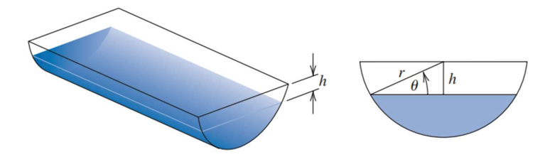

Suponga que 𝐿 = 10 𝑐𝑚, 𝑟 = 1 𝑐𝑚 y 𝑉 = 12.4 $cm^{3} $. Encuentre la profundidad del agua en el abrevadero dentro de 0.01 𝑐𝑚.

Datos: $$ 𝐿 = 10 𝑐𝑚 , 𝑟 = 1 𝑐𝑚 , 𝑉 = 12.4 cm^{3} $$ Ecuación del volumen: $$ V = L[0.5\pi r^{2} - r^{2}arcsen(h/r) -h(r^2 - h^2)^{\frac{1}{2}}] $$ Sustituyendo los valores: $$ 12.4 = 10[0.5\pi 1 - 1arcsen(h) -h\sqrt{(1 - h^2)}] $$ $$ 12.4 = 10[0.5\pi- arcsen(h) -h\sqrt{(1 - h^2)}] $$ $$ 1.24 = 0.5\pi- arcsen(h) -h\sqrt{(1 - h^2)} $$ Reorganizando: $$arcsen(h) + h\sqrt{(1 - h^2)} = 0.5\pi -1.24$$ $$ 1.5708 - 1.24 = 0.3308 $$ Ecuación final a resolver: $$0 = arcsen(h) + h\sqrt{(1 - h^2)} - 0.3308 $$

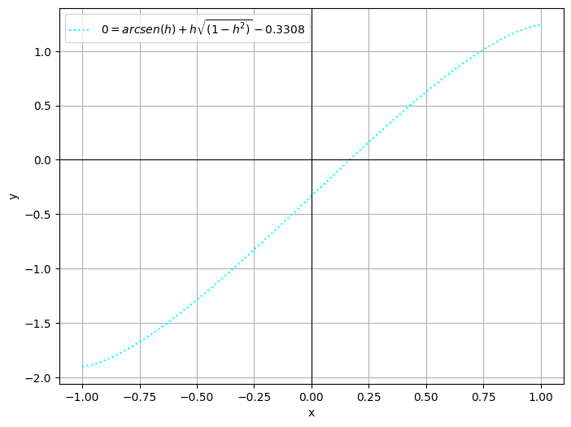

```
Intervalo inicial: [0, 0.5]
Iteración 1: c = 0.25, f(c) = 0.16394171428004223 rango = [0, 0.25]
Iteración 2: c = 0.125, f(c) = -0.08145257612578188 rango = [0.125, 0.25]
Iteración 3: c = 0.1875, f(c) = 0.04199099920862731 rango = [0.125, 0.1875]
Iteración 4: c = 0.15625, f(c) = -0.01957626345923502 rango = [0.15625, 0.1875]
Iteración 5: c = 0.171875, f(c) = 0.011249966179736282 rango = [0.15625, 0.171875]
Iteración 6: c = 0.1640625, f(c) = -0.004152997347499243 rango = [0.1640625, 0.171875]

Raíz aproximada: h = 0.16796875
```

```python
# a

x=np.linspace(-1, 1, 800)
y1 = np.arcsin(x) +  x*(1-x**2)**(1/2) - 0.3308

plt.figure(figsize=(8, 6)) #tamaño de la figura
plt.plot(x, y1, label='$0 = arcsen(h) + h\sqrt{(1 - h^2)} - 0.3308$', color='cyan', linestyle=':')
plt.xlabel('x')
plt.ylabel('y')

plt.grid(True)
plt.axhline(0, color='black', linewidth=0.8)  # Eje X
plt.axvline(0, color='black', linewidth=0.8)  # Eje Y
plt.legend()
plt.show()



def f(x):
    return np.arcsin(x) +  x*(1-x**2)**(1/2) - 0.3308

def biseccion(a, b, tol=1e-2, max_iter=50):
    print(f"\nIntervalo inicial: [{a}, {b}]")
    if f(a) * f(b) >= 0:
        print("El método de bisección no se puede aplicar: f(a) y f(b) deben tener signos opuestos.")
        return None

    iteracion = 0
    while abs(b - a) >= tol and iteracion < max_iter:
        c = (a + b) / 2.0

        if f(c) == 0:
            return c  # Se encontró la raíz exacta
        elif f(a) * f(c) < 0:
            b = c
        else:
            a = c
        iteracion += 1

        print(f"Iteración {iteracion}: c = {c}, f(c) = {f(c)} rango = [{a}, {b}]")
    return (a + b) / 2.0

# Intervalos
raiz = biseccion(0,0.5)
print(f"\nRaíz aproximada: h = {raiz}")
```

2. Un objeto que cae verticalmente a través del aire está sujeto a una resistencia viscosa, así como a la fuerza de gravedad. Suponga que un objeto con masa 𝑚 cae desde una altura $S_0$ y que la altura del objeto después de 𝑡 segundos es

$$ S(t) = S_0 - \frac{mg}{k} t + \frac{m^{2}g}{k^{2}} ( 1 - e^{-kt/m} ) $$

donde g = 9.81 $m/s^{2}$ y k representa el coeficiente de la resistencia del aire en $Ns/m$. Suponga $S_0$ = 300m, m = 0.25 kg y k = 0.1 Ns/m. Encuentre dentro de 0.01 𝑠𝑒𝑔𝑢𝑛𝑑𝑜𝑠, el tiempo que tarda un cuarto de kg en golpear el piso.

Datos: $$ g = 9.81 m/s^{2} , S_0 = 300m , m = 0.25 kg , k = 0.1 Ns/m, dentro de 0.01 𝑠𝑒𝑔𝑢𝑛𝑑𝑜𝑠 $$ Ecuación del volumen: $$ S(t) = S_0 - \frac{mg}{k} t + \frac{m^{2}g}{k^{2}} ( 1 - e^{-kt/m} ) $$ Sustituyendo los valores: $$ 0 = 300 - \frac{(0.25)(9.81)}{0.1} t + \frac{(0.25)^{2}(9.81)}{0.1^{2}} ( 1 - e^{-0.1t/0.25} ) $$ $$ 0 = 300 - \frac{2.4525}{0.1} t + \frac{0.613125}{0.01} ( 1 - e^{-0.4t} ) $$ Ecuación final a resolver: $$ 0 = 300 - 24.525 t + 61.3125 ( 1 - e^{-0.4t} ) $$

```python
def f(x):
    return 300 -24.525 * x + 61.3125 * ( 1 - np.e**(-0.4*x) )

def biseccion(a, b, tol=1e-2, max_iter=50):
    print(f"\nIntervalo inicial: [{a}, {b}]")
    if f(a) * f(b) >= 0:
        print("El método de bisección no se puede aplicar: f(a) y f(b) deben tener signos opuestos.")
        return None

    iteracion = 0
    while abs(b - a) >= tol and iteracion < max_iter:
        c = (a + b) / 2.0

        if f(c) == 0:
            return c  # Se encontró la raíz exacta
        elif f(a) * f(c) < 0:
            b = c
        else:
            a = c
        iteracion += 1

        print(f"Iteración {iteracion}: c = {c}, f(c) = {f(c)} rango = [{a}, {b}]","Error:",abs(b - a) )
    return (a + b) / 2.0

# Intervalos
raiz = biseccion(14,15,)
print(f"\nRaíz aproximada: t = {raiz}")
```

```
Intervalo inicial: [14, 15]
Iteración 1: c = 14.5, f(c) = 5.514373049674191 rango = [14.5, 15] Error: 0.5
Iteración 2: c = 14.75, f(c) = -0.599212210450716 rango = [14.5, 14.75] Error: 0.25
Iteración 3: c = 14.625, f(c) = 2.457801182869744 rango = [14.625, 14.75] Error: 0.125
Iteración 4: c = 14.6875, f(c) = 0.9293483059481531 rango = [14.6875, 14.75] Error: 0.0625
Iteración 5: c = 14.71875, f(c) = 0.16508133502446043 rango = [14.71875, 14.75] Error: 0.03125
Iteración 6: c = 14.734375, f(c) = -0.21706213662302076 rango = [14.71875, 14.734375] Error: 0.015625
Iteración 7: c = 14.7265625, f(c) = -0.02598957294580373 rango = [14.71875, 14.7265625] Error: 0.0078125

Raíz aproximada: t = 14.72265625
```

### EJERCICIOS TEÓRICOS

1. Use el teorema 2.1 para encontrar una cota para el número de iteraciones necesarias para lograr una aproximación con precisión de $10^{-4}$ para la solución de $x^{3}-x-1=0$ que se encuentra dentro del intervalo [1, 2]. Encuentre una aproximación para la raíz con este grado de precisión

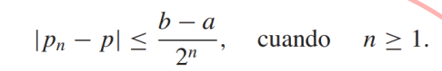

```python
def f(x):
    return x**3-x-1

def biseccion(a, b, tol=1e-4, max_iter=50):
    print(f"\nIntervalo inicial: [{a}, {b}]")
    if f(a) * f(b) >= 0:
        print("El método de bisección no se puede aplicar: f(a) y f(b) deben tener signos opuestos.")
        return None

    iteracion = 0
    while abs(b - a) >= tol and iteracion < max_iter:
        c = (a + b) / 2.0

        if f(c) == 0:
            return c  # Se encontró la raíz exacta
        elif f(a) * f(c) < 0:
            b = c
        else:
            a = c
        iteracion += 1

        print(f"Iteración {iteracion}: c = {c}, f(c) = {f(c)} rango = [{a}, {b}]","Error:",abs(b - a) )

    return (a + b) / 2.0 , iteracion


# Intervalos
raiz = biseccion(1,2)
print(f"\nRaíz aproximada: t = {raiz} ")
```

```
Intervalo inicial: [1, 2]
Iteración 1: c = 1.5, f(c) = 0.875 rango = [1, 1.5] Error: 0.5
Iteración 2: c = 1.25, f(c) = -0.296875 rango = [1.25, 1.5] Error: 0.25
Iteración 3: c = 1.375, f(c) = 0.224609375 rango = [1.25, 1.375] Error: 0.125
Iteración 4: c = 1.3125, f(c) = -0.051513671875 rango = [1.3125, 1.375] Error: 0.0625
Iteración 5: c = 1.34375, f(c) = 0.082611083984375 rango = [1.3125, 1.34375] Error: 0.03125
Iteración 6: c = 1.328125, f(c) = 0.014575958251953125 rango = [1.3125, 1.328125] Error: 0.015625
Iteración 7: c = 1.3203125, f(c) = -0.018710613250732422 rango = [1.3203125, 1.328125] Error: 0.0078125
Iteración 8: c = 1.32421875, f(c) = -0.0021279454231262207 rango = [1.32421875, 1.328125] Error: 0.00390625
Iteración 9: c = 1.326171875, f(c) = 0.006208829581737518 rango = [1.32421875, 1.326171875] Error: 0.001953125
Iteración 10: c = 1.3251953125, f(c) = 0.002036650665104389 rango = [1.32421875, 1.3251953125] Error: 0.0009765625
Iteración 11: c = 1.32470703125, f(c) = -4.659488331526518e-05 rango = [1.32470703125, 1.3251953125] Error: 0.00048828125
Iteración 12: c = 1.324951171875, f(c) = 0.000994790971162729 rango = [1.32470703125, 1.324951171875] Error: 0.000244140625
Iteración 13: c = 1.3248291015625, f(c) = 0.00047403881944774184 rango = [1.32470703125, 1.3248291015625] Error: 0.0001220703125
Iteración 14: c = 1.32476806640625, f(c) = 0.00021370716262936185 rango = [1.32470703125, 1.32476806640625] Error: 6.103515625e-05

Raíz aproximada: t = (1.324737548828125, 14)
```

2. La función definida por 𝑓(𝑥) = sin 𝜋 𝑥 tiene ceros en cada entero. Muestre cuando −1 < 𝑎 < 0 y 2 < 𝑏 < 3, el método de bisección converge a

   a. 0, si a+b < 2

   b. 2, si a+b > 2

   c. 1, si a+b = 2

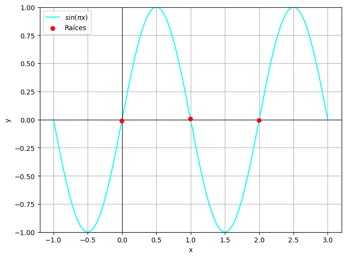

```python
# Definir el rango de x y la función
x = np.linspace(-1, 3, 800)
y1 = np.sin(np.pi*x)

# Crear la figura
plt.figure(figsize=(8, 6))
plt.plot(x, y1, label='$sin(\pi x)$' , color='cyan')
plt.xlabel('x')
plt.ylabel('y')

# Añadir ejes y cuadrícula
plt.grid(True)
plt.axhline(0, color='black', linewidth=0.8)  # Eje X
plt.axvline(0, color='black', linewidth=0.8)  # Eje Y

# Encontrar las raíces (aproximadas)
# Usamos np.diff para detectar cambios de signo en y1
roots_indices = np.where(np.diff(np.sign(y1)))[0]
roots_x = x[roots_indices]
roots_y = y1[roots_indices]

# Marcar las raíces con puntos rojos
plt.scatter(roots_x, roots_y, color='red', label='Raíces', zorder=5)

# Ajustar límites y leyenda
plt.ylim(-1, 1)
plt.legend()

plt.show()
```

punto medio inicial: $$ m_o = \frac{a+b}{2}$$

Este punto medio determinará en qué subintervalo se continúa el proceso de bisección, dependiendo del signo de $f(m_0)$ que nos indica hacia dónde se dirige la convergencia.